MLRA: 17, 15, 18, 22A  
report version 0.3  
2017-04-18

This report is designed to provide statistical summaries of the environmental properties for one or more MLRA Summaries are based on raster data extracted from [fixed-density sampling of map unit polygons](http://ncss-tech.github.io/AQP/sharpshootR/sample-vs-population.html).

### Modified Box and Whisker Plots

Whiskers extend from the 5th to 95th [percentiles](https://en.wikipedia.org/wiki/Percentile), the body represents the 25th through 75th percentiles, and the dot is the 50th percentile.

**Suggested usage:**

- Gauge overlap between map units in terms of boxes (25th-75th percentiles) and whiskers (5th-95th percentiles).
- Non-overlapping boxes are a strong indication that the central tendencies (of select raster data) differ.
- Distribution shape is difficult to infer from box and whisker plots, remember to cross-reference with density plots below.

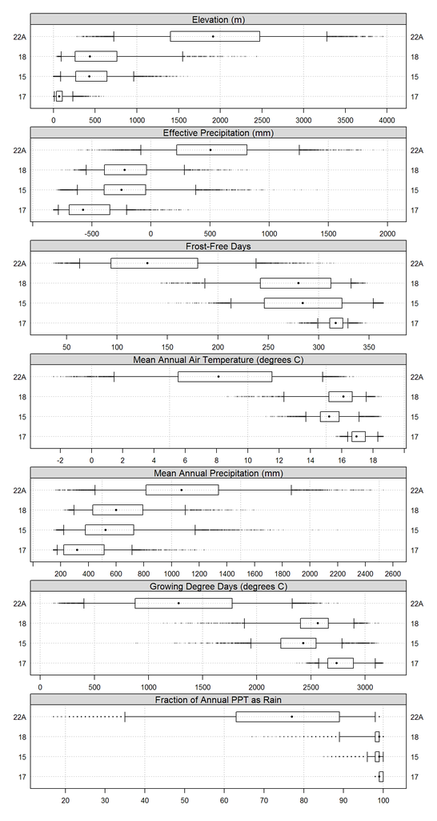

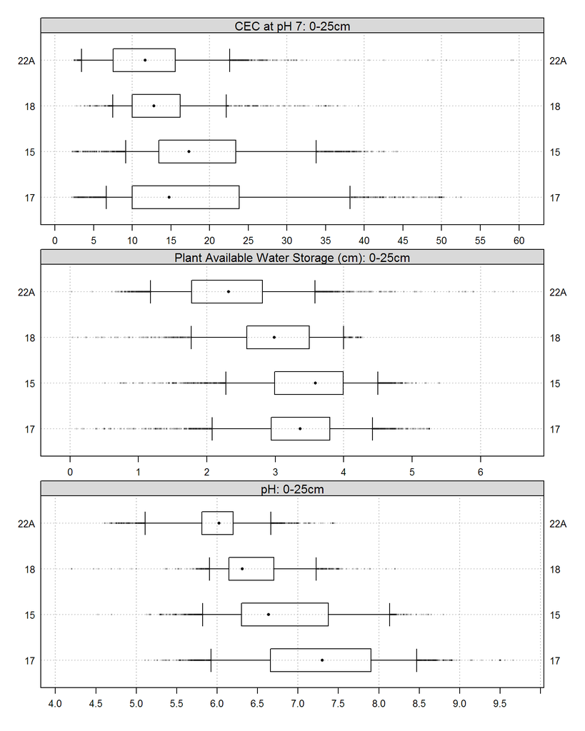

### Density Plots

These plots are a smooth alternative ([denisty estimation](https://en.wikipedia.org/wiki/Density_estimation)) to the classic "binned" ([histogram](https://en.wikipedia.org/wiki/Histogram)) approach to visualizing distributions. Peaks correspond to values that are most frequent within a data set. Each data set (ID / variable) are rescaled to {0,1} so that the y-axis can be interpreted as the "relative proportion of samples".

**Suggested usage:**

- Density plots depict a more detailed summary of distribution shape.
- When making comparisons, be sure to look for:
- multiple peaks
- narrow peaks vs. wide "mounds"
- short vs. long "tails"

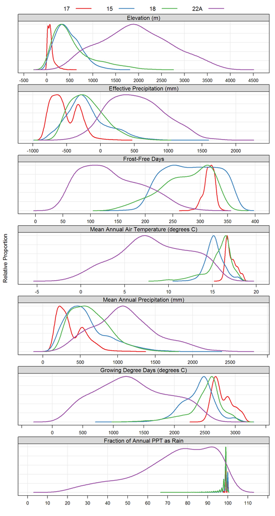

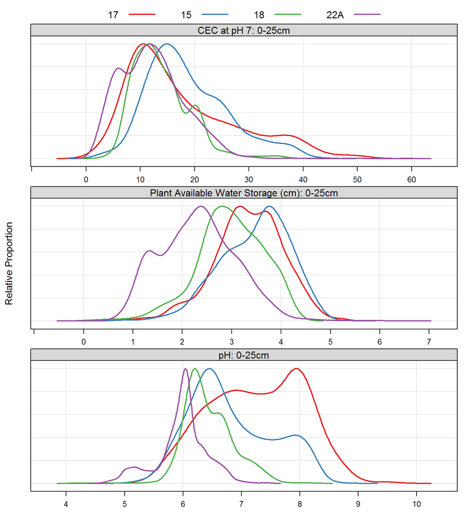

### Tabular Summaries

Table of select [percentiles](https://en.wikipedia.org/wiki/Percentile), by variable. In these tables, headings like "Q5" can be interpreted as the the "5th percentile"; 5% of the data are less than this value. The 50th percentile ("Q50") is the median.

Median Values

| MLRA | Elevation (m) | Effective Precipitation (mm) | Frost-Free Days | Mean Annual Air Temperature (degrees C) | Mean Annual Precipitation (mm) | Growing Degree Days (degrees C) | Fraction of Annual PPT as Rain |
| --- | --- | --- | --- | --- | --- | --- | --- |
| 17 | 68 | -572.26 | 317 | 16.94 | 319 | 2737 | 99 |
| 15 | 429 | -248.00 | 284 | 15.19 | 525 | 2431 | 99 |
| 18 | 436 | -223.40 | 280 | 16.10 | 600 | 2563 | 99 |
| 22A | 1913 | 503.97 | 130 | 8.11 | 1073 | 1280 | 77 |

Elevation (m)

| MLRA | Q5 | Q10 | Q25 | Q50 | Q75 | Q90 | Q95 |
| --- | --- | --- | --- | --- | --- | --- | --- |
| 17 | 9.00 | 15.0 | 33 | 68 | 105.00 | 176.0 | 231.0 |
| 15 | 85.05 | 142.0 | 265 | 429 | 641.00 | 839.0 | 964.0 |
| 18 | 91.00 | 138.0 | 259 | 436 | 760.00 | 1254.4 | 1548.2 |
| 22A | 723.55 | 912.1 | 1402 | 1913 | 2475.25 | 3006.9 | 3279.0 |

Effective Precipitation (mm)

| MLRA | Q5 | Q10 | Q25 | Q50 | Q75 | Q90 | Q95 |
| --- | --- | --- | --- | --- | --- | --- | --- |
| 17 | -781.41 | -761.27 | -690.34 | -572.26 | -347.98 | -267.31 | -205.48 |
| 15 | -620.91 | -549.01 | -396.52 | -248.00 | -44.47 | 255.73 | 378.47 |
| 18 | -548.05 | -495.68 | -392.04 | -223.40 | -36.85 | 153.54 | 283.39 |
| 22A | -85.90 | 29.78 | 217.71 | 503.97 | 811.09 | 1098.16 | 1254.87 |

Frost-Free Days

| MLRA | Q5 | Q10 | Q25 | Q50 | Q75 | Q90 | Q95 |
| --- | --- | --- | --- | --- | --- | --- | --- |
| 17 | 299 | 303 | 311 | 317 | 324 | 327 | 329 |
| 15 | 213 | 222 | 246 | 284 | 323 | 346 | 354 |
| 18 | 187 | 206 | 242 | 280 | 312 | 325 | 332 |
| 22A | 63 | 71 | 94 | 130 | 180 | 220 | 238 |

Mean Annual Air Temperature (degrees C)

| MLRA | Q5 | Q10 | Q25 | Q50 | Q75 | Q90 | Q95 |
| --- | --- | --- | --- | --- | --- | --- | --- |
| 17 | 16.37 | 16.51 | 16.65 | 16.94 | 17.50 | 17.97 | 18.29 |
| 15 | 13.71 | 14.05 | 14.63 | 15.19 | 15.83 | 16.57 | 17.10 |
| 18 | 12.31 | 13.36 | 15.17 | 16.10 | 16.66 | 17.12 | 17.56 |
| 22A | 1.44 | 2.70 | 5.53 | 8.11 | 11.53 | 13.96 | 14.77 |

Mean Annual Precipitation (mm)

| MLRA | Q5 | Q10 | Q25 | Q50 | Q75 | Q90 | Q95 |
| --- | --- | --- | --- | --- | --- | --- | --- |
| 17 | 175.0 | 189.0 | 222.0 | 319 | 515 | 639.0 | 716.0 |
| 15 | 223.0 | 270.1 | 378.0 | 525 | 728 | 1013.9 | 1171.9 |
| 18 | 295.8 | 331.0 | 432.0 | 600 | 793 | 961.0 | 1100.0 |
| 22A | 449.0 | 565.0 | 815.5 | 1073 | 1340 | 1674.9 | 1866.9 |

Growing Degree Days (degrees C)

| MLRA | Q5 | Q10 | Q25 | Q50 | Q75 | Q90 | Q95 |
| --- | --- | --- | --- | --- | --- | --- | --- |
| 17 | 2573.0 | 2607 | 2655.00 | 2737 | 2893 | 3026.0 | 3095.00 |
| 15 | 1947.0 | 2052 | 2222.25 | 2431 | 2549 | 2673.9 | 2787.95 |
| 18 | 1886.8 | 2089 | 2405.00 | 2563 | 2661 | 2799.4 | 2898.20 |
| 22A | 403.0 | 536 | 876.00 | 1280 | 1773 | 2181.9 | 2328.00 |

Fraction of Annual PPT as Rain

| MLRA | Q5 | Q10 | Q25 | Q50 | Q75 | Q90 | Q95 |
| --- | --- | --- | --- | --- | --- | --- | --- |
| 17 | 99 | 99 | 99 | 99 | 100 | 100 | 100 |
| 15 | 96 | 97 | 98 | 99 | 99 | 100 | 100 |
| 18 | 89 | 93 | 98 | 99 | 99 | 99 | 99 |
| 22A | 35 | 44 | 63 | 77 | 89 | 96 | 98 |

### Geomorphon Landform Classification

Proportion of samples within each map unit that correspond to 1 of 10 possible landform positions, as generated via [geomorphon](https://grass.osgeo.org/grass70/manuals/addons/r.geomorphon.html) algorithm. Landform classification by [this method](http://dx.doi.org/10.1016/j.geomorph.2012.11.005) is scale-invariant and is therefore not affected by computational window size selection.

**Suggested usage:**

- Use the graphical summary to identify patterns, then consult the tabular representation for specifics.
- "Flat" is based on a 3% slope threshold.
- Map units are organized (in the figure) according to the similarity, computed from proportions of each landform position.
- The [dendrogram](http://ncss-tech.github.io/stats_for_soil_survey/chapter_5.html) on the right side of the figure describes relative similarity. "Lower branch height" (e.g. closer to the right-hand side of the figure) denotes more similar landform positions.
- Landform class labels and colors are aligned with an idealized *shedding* → *accumulating* hydrologic gradient.

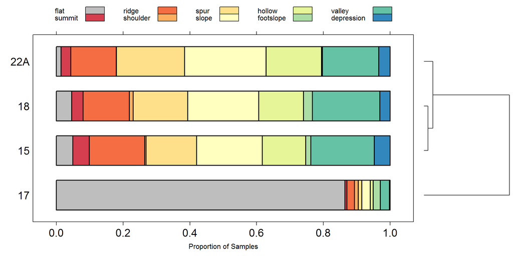

| mlra | flat | summit | ridge | shoulder | spur | slope | hollow | footslope | valley | depression |
| --- | --- | --- | --- | --- | --- | --- | --- | --- | --- | --- |
| 17 | 0.864 | 0.006 | 0.023 | 0.011 | 0.011 | 0.025 | 0.009 | 0.021 | 0.028 | 0.002 |
| 15 | 0.050 | 0.049 | 0.166 | 0.004 | 0.152 | 0.196 | 0.130 | 0.016 | 0.190 | 0.048 |
| 18 | 0.046 | 0.034 | 0.139 | 0.011 | 0.164 | 0.212 | 0.135 | 0.026 | 0.202 | 0.031 |
| 22A | 0.014 | 0.029 | 0.136 | 0.001 | 0.204 | 0.244 | 0.166 | 0.002 | 0.169 | 0.034 |

### Landcover Summary

These values are from the [2011 NLCD](https://www.mrlc.gov/nlcd2011.php) (30m) database.

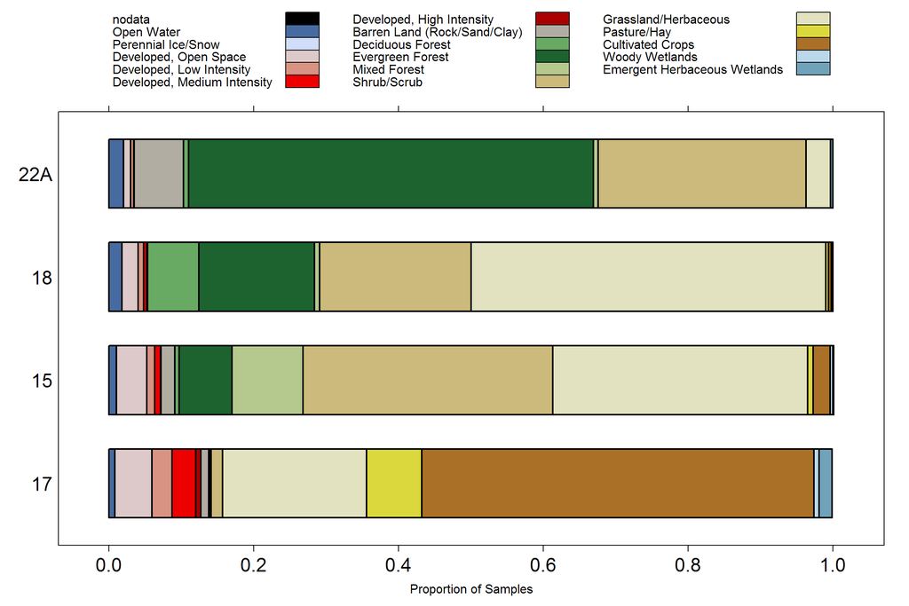

| mlra | nodata | Open Water | Perennial Ice/Snow | Developed, Open Space | Developed, Low Intensity | Developed, Medium Intensity | Developed, High Intensity | Barren Land (Rock/Sand/Clay) | Deciduous Forest | Evergreen Forest | Mixed Forest | Shrub/Scrub | Grassland/Herbaceous | Pasture/Hay | Cultivated Crops | Woody Wetlands | Emergent Herbaceous Wetlands |
| --- | --- | --- | --- | --- | --- | --- | --- | --- | --- | --- | --- | --- | --- | --- | --- | --- | --- |
| 17 | 0 | 0.01 | 0 | 0.05 | 0.03 | 0.03 | 0.01 | 0.01 | 0.00 | 0.00 | 0.00 | 0.02 | 0.20 | 0.08 | 0.54 | 0.01 | 0.02 |
| 15 | 0 | 0.01 | 0 | 0.04 | 0.01 | 0.01 | 0.00 | 0.02 | 0.01 | 0.07 | 0.10 | 0.34 | 0.35 | 0.01 | 0.02 | 0.00 | 0.00 |
| 18 | 0 | 0.02 | 0 | 0.02 | 0.01 | 0.00 | 0.00 | 0.00 | 0.07 | 0.16 | 0.01 | 0.21 | 0.49 | 0.00 | 0.00 | 0.00 | 0.00 |
| 22A | 0 | 0.02 | 0 | 0.01 | 0.00 | 0.00 | 0.00 | 0.07 | 0.01 | 0.56 | 0.01 | 0.29 | 0.03 | 0.00 | 0.00 | 0.00 | 0.00 |

### Multivariate Summary

This plot displays the similarity of the map units across the set of environmental variables used in this report. The contours contain 75% (dotted line), 50% (dashed line), and 25% (solid line) of the points in an optimal [2D projection](https://en.wikipedia.org/wiki/Multidimensional_scaling#Non-metric_multidimensional_scaling) of multivariate data space. Data from map units with more than 1,000 samples are (sub-sampled via [cLHS](https://en.wikipedia.org/wiki/Latin_hypercube_sampling)). Map units with very low variation in environmental variables can result in tightly clustered points in the 2D projection. It is not possible to generate a multivariate summary when any sampled variable (e.g. slope) has a near-zero variance. See [this chapter](http://ncss-tech.github.io/stats_for_soil_survey/chapter_5.html), from the new *Statistics for Soil Scientists* NEDS course, for an soils-specific introduction to these concepts.

**Suggested usage:**

- The relative position of points and contours are meaningful; absolute position will vary each time the report is run.
- Colors match those used in the density plots above. Be sure to cross-reference this figure with density plots.
- Look for "diffuse" vs. "concentrated" clusters: these suggest relatively broadly vs. narrowly defined map unit concepts.
- Multiple, disconnected contours (per map unit) could indicate errors or small map unit separated by large distances. Check for multiple peaks in the associated density plots.
- Nesting of clusters (e.g. smaller cluster contained by larger cluster) suggests superset/subset relationships.
- Overlap is proportional to similarity.

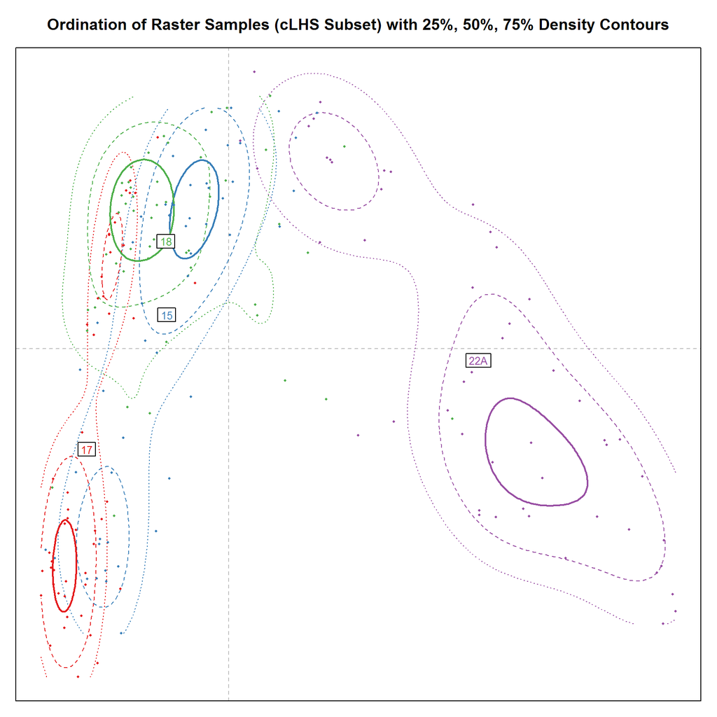

### Raster Data Correlation

The following figure highlights shared information among raster data sources based on [Spearman's Ranked Correlation coefficient](https://en.wikipedia.org/wiki/Spearman%27s_rank_correlation_coefficient). Branch height is associated with the degree of shared information between raster data.

**Suggested usage:**

- Look for clustered sets of raster data: typically PRISM-derived and elevation data are closely correlated.
- Highly correlated raster data sources reduce the reliability of the "raster data importance" figure.

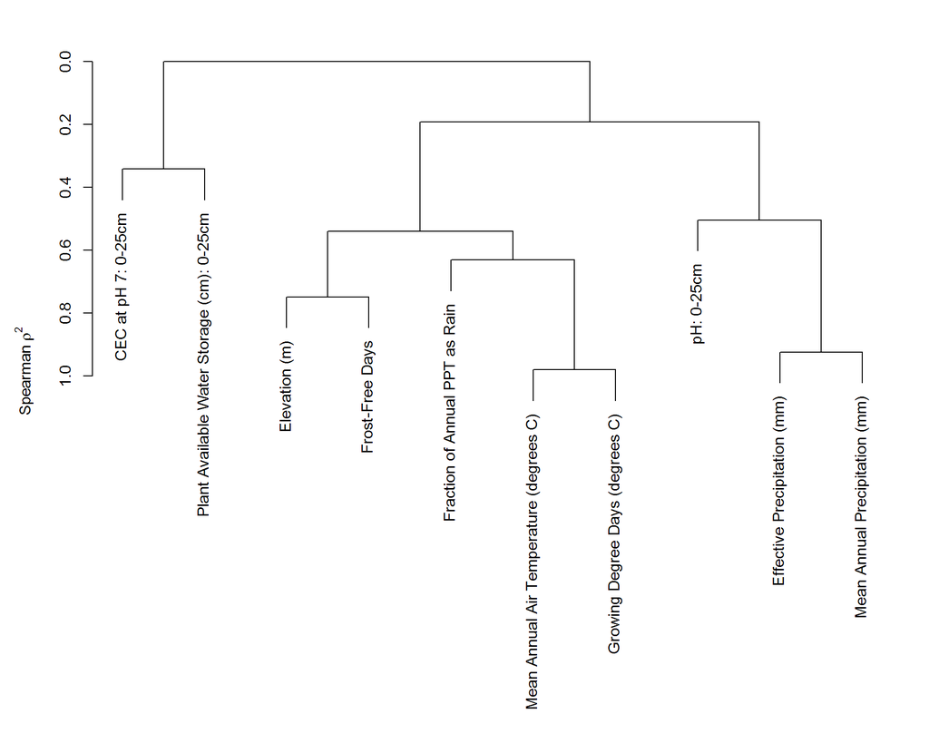

### Raster Data Importance

The following figure ranks raster data sources in terms of how accurately each can be used to discriminate between map unit concepts.

**Suggested usage:**

- Map unit concepts are more consistently predicted (by supervised classification) using those raster data sources with relatively larger "Mean Decrease in Accuracy" values.
- Highly correlated raster data sources will "compete" for positions in this figure. For example, if *elevation* and *mean annual air temperature* are highly correlated, then their respective "importance" values are interchangeable.

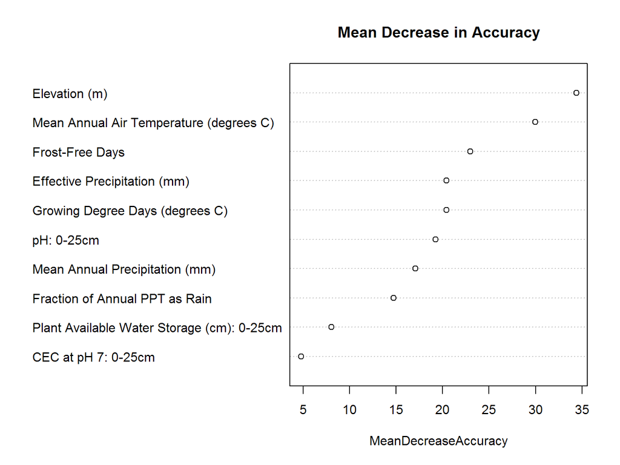

Report [configuration and source code are hosted on GitHub](https://github.com/ncss-tech/soilReports).